# Лабораторная работа №2

```python
import numpy as np

import seaborn as sns
from matplotlib import pyplot as plt

from sklearn.datasets import make_moons
from sklearn.model_selection import train_test_split

import torch
from torch import nn
from torch.nn import functional as F

from torch.utils.data import TensorDataset, DataLoader
from torch import manual_seed

from tqdm.notebook import tqdm

import sys
import collections
if sys.version_info.major == 3 and sys.version_info.minor >= 10:
    from collections.abc import MutableMapping
else:
    from collections import MutableMapping

sns.set(style="darkgrid", font_scale=1.4)
```

## Logistic regression is my profession

**Напоминание** Давайте вспоним, что происходит в логистической регрессии. На входе у нас есть матрица объект-признак X и столбец-вектор $y$ – метки из $\{0, 1\}$ для каждого объекта. Мы хотим найти такую матрицу весов $W$ и смещение $b$ (bias), что наша модель $XW + b$ будет каким-то образом предсказывать класс объекта. Как видно на выходе наша модель может выдавать число в интервале от $(-\infty;\infty)$. Этот выход как правило называют "логитами" (logits). Нам необходимо перевести его на интервал от $[0;1]$ для того, чтобы он выдавал нам вероятность принадлежности объекта к классу один, также лучше, чтобы эта функция была монотонной, быстро считалась, имела производную и на $-\infty$ имела значение $0$, а на $+\infty$ имела значение $1$. Такой класс функций называется сигмоиды. Чаще всего в качестве сигмоида берут $$ \sigma(x) = \frac{1}{1 + e^{-x}}. $$

### Задание

Вам необходимо написать модуль на PyTorch реализующий $logits = XW + b$, где $W$ и $b$ – параметры (`nn.Parameter`) модели. Иначе говоря здесь мы реализуем своими руками модуль `nn.Linear` (в этом пункте его использование запрещено). Инициализируйте веса нормальным распределением (`torch.randn`).

```python
class LinearRegression(nn.Module):
    def __init__(self, in_features: int, out_features: int, bias: bool = True):
        super().__init__()
        self.weights = nn.Parameter(torch.randn(out_features, in_features))
        self.bias = bias
        if bias:
            self.bias_term = nn.Parameter(torch.randn(out_features))

    def forward(self, x):
        x = x @ self.weights.t()
        if self.bias:
            x +=  self.bias_term
        return x
```

### Датасет

Давайте сгенерируем датасет и посмотрим на него!

```python
X, y = make_moons(n_samples=10000, random_state=42, noise=0.1)
```

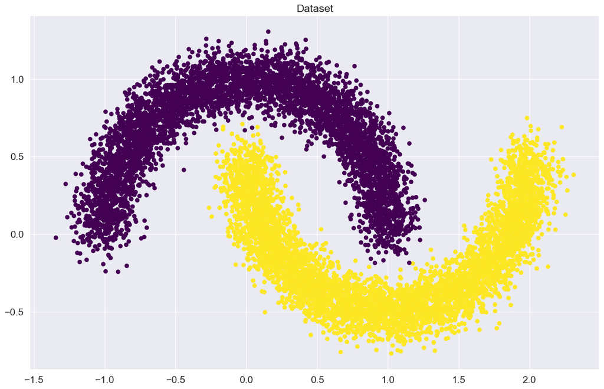

```python
plt.figure(figsize=(16, 10))
plt.title("Dataset")
plt.scatter(X[:, 0], X[:, 1], c=y, cmap="viridis")
plt.show()
```

Сделаем train/test split

```python
X_train, X_val, y_train, y_val = train_test_split(X, y, random_state=42)
```

### Загрузка данных

В PyTorch загрузка данных как правило происходит налету (иногда датасеты не помещаются в оперативную память). Для этого используются две сущности `Dataset` и `DataLoader`.

1. `Dataset` загружает каждый объект по отдельности.
2. `DataLoader` группирует объекты из `Dataset` в батчи.

Так как наш датасет достаточно маленький мы будем использовать `TensorDataset`. Все, что нам нужно, это перевести из массива numpy в тензор с типом `torch.float32`.

```python
X_train_t =  torch.from_numpy(X_train).to(torch.float32)
y_train_t =  torch.from_numpy(y_train).to(torch.float32)
X_val_t =  torch.from_numpy(X_val).to(torch.float32)
y_val_t =  torch.from_numpy(y_val).to(torch.float32)
```

Создаем `Dataset` и `DataLoader`.

```python
train_dataset = TensorDataset(X_train_t, y_train_t)
val_dataset = TensorDataset(X_val_t, y_val_t)
train_dataloader = DataLoader(train_dataset, batch_size=128)
val_dataloader = DataLoader(val_dataset, batch_size=128)
```

```python
manual_seed(42)
linear_regression = LinearRegression(2, 1)
loss_function = nn.BCEWithLogitsLoss()
optimizer = torch.optim.SGD(linear_regression.parameters(), lr=0.05)
```

**Вопрос 1** Сколько обучаемых параметров у получившейся модели?

**Ответ:** (in_features * out_features) + out_features (если bias == True)  
(2 * 1) + 1 = 3

```python
for elem in linear_regression.parameters():
    print(elem)
```

```
Parameter containing:
tensor([[0.3367, 0.1288]], requires_grad=True)
Parameter containing:
tensor([0.2345], requires_grad=True)
```

### Train loop

Вот псевдокод, который поможет вам разобраться в том, что происходит во время обучения

```
for epoch in range(max_epochs):  # <----------- итерируемся по датасету несколько раз
    for x_batch, y_batch in dataset:  # <------ итерируемся по датасету. Так как мы используем SGD а не GD, то берем батчи заданного размера
        optimizer.zero_grad()  # <------------- обуляем градиенты модели
        outp = model(x_batch)  # <------------- получаем "логиты" из модели
        loss = loss_func(outp, y_batch)  # <--- считаем "лосс" для логистической регрессии
        loss.backward()  # <------------------- считаем градиенты
        optimizer.step()  # <------------------ делаем шаг градиентного спуска
        if convergence:  # <------------------- в случае сходимости выходим из цикла
            break
```

В коде ниже добавлено логирование `accuracy` и `loss`.

```python
tol = 1e-3
losses = []
max_epochs = 100
prev_weights = torch.zeros_like(linear_regression.weights)
stop_it = False
for epoch in range(max_epochs):
    manual_seed(42 + epoch)
    for it, (X_batch, y_batch) in enumerate(train_dataloader):
        optimizer.zero_grad()
        outp = linear_regression(X_batch)
        loss =  loss_function(outp.flatten(), y_batch)
        loss.backward()
        losses.append(loss.detach().flatten()[0])
        optimizer.step()
        probabilities = torch.sigmoid(outp)
        preds = (probabilities>0.5).type(torch.long)
        batch_acc = (preds.flatten() == y_batch).type(torch.float32).sum()/y_batch.size(0)
        if it % 500000 == 0:
            print(f"Iteration: {it + epoch*len(train_dataset)}\nBatch accuracy: {batch_acc}")
        current_weights = linear_regression.weights.detach().clone()
        if (prev_weights - current_weights).abs().max() < tol:
            print(f"\nIteration: {it + epoch*len(train_dataset)}.Convergence. Stopping iterations.")
            stop_it = True
            break
        prev_weights = current_weights
    if stop_it:
        break
```

```
Iteration: 0
Batch accuracy: 0.5625
Iteration: 7500
Batch accuracy: 0.765625
Iteration: 15000
Batch accuracy: 0.7890625
Iteration: 22500
Batch accuracy: 0.7890625
Iteration: 30000
Batch accuracy: 0.8046875
Iteration: 37500
Batch accuracy: 0.8046875
Iteration: 45000
Batch accuracy: 0.8046875
Iteration: 52500
Batch accuracy: 0.8203125
Iteration: 60000
Batch accuracy: 0.8203125
Iteration: 67500
Batch accuracy: 0.8203125
Iteration: 75000
Batch accuracy: 0.8203125
Iteration: 82500
Batch accuracy: 0.8203125
Iteration: 90000
Batch accuracy: 0.8203125

Iteration: 90047.Convergence. Stopping iterations.
```

**Вопрос 2**

Сколько итераций потребовалось, чтобы алгоритм сошелся?

### Визуализируем результаты

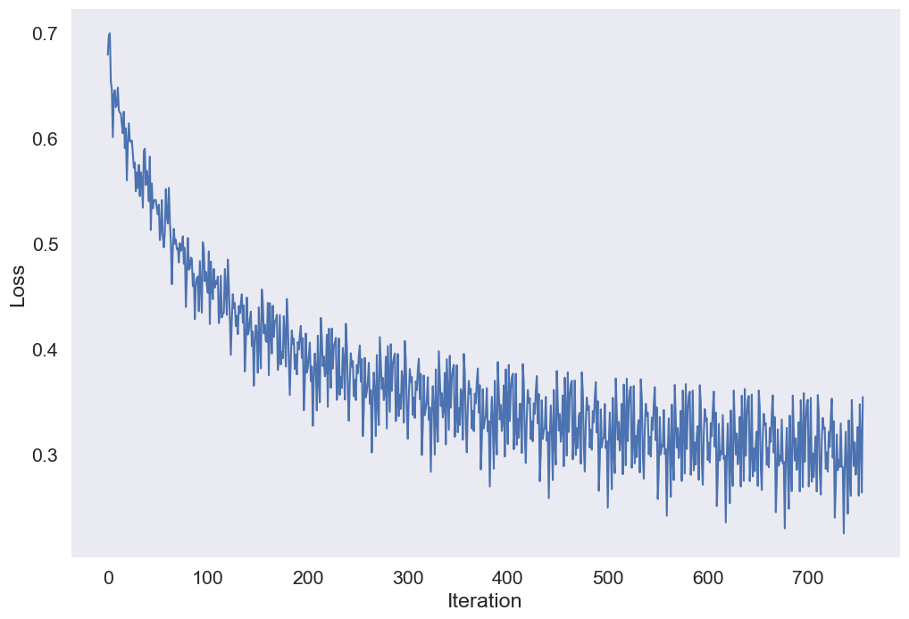

```python
plt.figure(figsize=(12, 8))
plt.plot(range(len(losses)), losses)
plt.xlabel("Iteration")
plt.ylabel("Loss")
plt.grid()
plt.show()
```

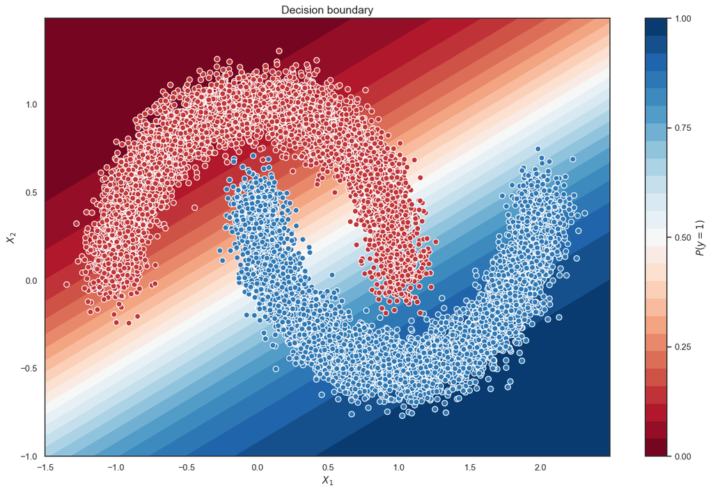

```python
import numpy as np

sns.set(style="white")

xx, yy = np.mgrid[-1.5:2.5:.01, -1.:1.5:.01]
grid = np.c_[xx.ravel(), yy.ravel()]
batch = torch.from_numpy(grid).type(torch.float32)
with torch.no_grad():
    probs = torch.sigmoid(linear_regression(batch).reshape(xx.shape))
    probs = probs.numpy().reshape(xx.shape)

f, ax = plt.subplots(figsize=(16, 10))
ax.set_title("Decision boundary", fontsize=14)
contour = ax.contourf(xx, yy, probs, 25, cmap="RdBu",
                      vmin=0, vmax=1)
ax_c = f.colorbar(contour)
ax_c.set_label("$P(y = 1)$")
ax_c.set_ticks([0, .25, .5, .75, 1])

ax.scatter(X[100:,0], X[100:, 1], c=y[100:], s=50,
           cmap="RdBu", vmin=-.2, vmax=1.2,
           edgecolor="white", linewidth=1)

ax.set(xlabel="$X_1$", ylabel="$X_2$")
plt.show()
```

```python
@torch.no_grad()
def predict(dataloader, model):
    model.eval()
    predictions = np.array([])
    for x_batch, _ in dataloader:
        outp = model(x_batch)
        probs = torch.sigmoid(outp)
        preds = (probs > 0.5).type(torch.long)
        predictions = np.hstack((predictions, preds.numpy().flatten()))
    predictions = predictions
    return predictions.flatten()
```

```python
from sklearn.metrics import accuracy_score

accuracy_score(y_val_t, predict(val_dataloader, linear_regression))
```

```
0.862
```

**Вопрос 3**

Какое `accuracy` получается после обучения?

**Ответ:** 86.2%

### MNIST

```python
import os
import torchvision.transforms as transforms
import torchvision.datasets as dsets

BATCH_SIZE = 128

root = os.getcwd()

train_dataset = dsets.MNIST(root=root, train=True, transform=transforms.ToTensor(), download=True)
val_dataset = dsets.MNIST(root=root, train=False, transform=transforms.ToTensor())

train_dataloader = DataLoader(train_dataset)
valid_dataloader =  DataLoader(val_dataset)
```

```python
class Identical(nn.Module):
    def forward(self, x):
        return x

class Flatten(nn.Module):
    def forward(self, x):
        batch_size = x.size(0)
        return x.view(batch_size, -1)
```

```python
device = "mps" if torch.backends.mps.is_available() else "cpu"
```

```python
activation = nn.ELU

model = nn.Sequential(
    Flatten(),
    nn.Linear(28*28, 128),
    activation(),
    nn.Linear(128, 128),
    activation(),
    nn.Linear(128, 10)
)
```

```python
criterion = nn.CrossEntropyLoss()
optimizer = torch.optim.Adam(model.parameters())

loaders = {"train": train_dataloader, "valid": valid_dataloader}
```

### Train loop

Давайте разберемся с кодом ниже, который подойдет для 90% задач в будущем.

```
for epoch in range(max_epochs):  # <--------------- итерируемся по датасету несколько раз
    for k, dataloader in loaders.items():  # <----- несколько dataloader для train / valid / test
        for x_batch, y_batch in dataloader:  # <--- итерируемся по датасету. Так как мы используем SGD а не GD, то берем батчи заданного размера
            if k == "train":
                model.train()  # <------------------ переводим модель в режим train
                optimizer.zero_grad()  # <--------- обнуляем градиенты модели
                outp = model(x_batch)
                loss = criterion(outp, y_batch) # <-считаем "лосс" для логистической регрессии
                loss.backward()  # <--------------- считаем градиенты
                optimizer.step()  # <-------------- делаем шаг градиентного спуска
            else:  # <----------------------------- test/eval
                model.eval()  # <------------------ переводим модель в режим eval
                with torch.no_grad():  # <--------- НЕ считаем градиенты
                    outp = model(x_batch)  # <------------- получаем "логиты" из модели
            count_metrics(outp, y_batch)  # <-------------- считаем метрики
```

```python
max_epochs = 10
accuracy = {"train": [], "valid": []}
for epoch in range(max_epochs):
    epoch_correct = 0
    epoch_all = 0
    manual_seed(42 + epoch)
    for k, dataloader in loaders.items():
        for x_batch, y_batch in tqdm(dataloader, leave=False):
            if k == "train":
                model.train()
                optimizer.zero_grad()
                outp = model(x_batch)
                loss = criterion(outp, y_batch)
                loss.backward()
                optimizer.step()
            else:
                 model.eval()
                 with torch.no_grad():
                     outp = model(x_batch)

            preds = outp.argmax(-1)
            correct = (preds == y_batch).sum()
            all = y_batch.size(0)
            epoch_correct += correct.item()
            epoch_all += all

        if k == "train":
            print(f"Epoch: {epoch+1}")
        print(f"Loader: {k}. Accuracy: {epoch_correct/epoch_all}")
        accuracy[k].append(epoch_correct/epoch_all)
```

```
Epoch: 1
Loader: train. Accuracy: 0.9312166666666667
```

```
Loader: valid. Accuracy: 0.9304571428571429
```

```
Epoch: 2
Loader: train. Accuracy: 0.9623833333333334
```

```
Loader: valid. Accuracy: 0.9613
```

```
Epoch: 3
Loader: train. Accuracy: 0.9685166666666667
```

```
Loader: valid. Accuracy: 0.9660142857142857
```

```
Epoch: 4
Loader: train. Accuracy: 0.97305
```

```
Loader: valid. Accuracy: 0.9711428571428572
```

```
Epoch: 5
Loader: train. Accuracy: 0.9764166666666667
```

```
Loader: valid. Accuracy: 0.9729714285714286
```

```
Epoch: 6
Loader: train. Accuracy: 0.9775333333333334
```

```
Loader: valid. Accuracy: 0.9755857142857143
```

```
Epoch: 7
Loader: train. Accuracy: 0.9794
```

```
Loader: valid. Accuracy: 0.9772714285714286
```

```
Epoch: 8
Loader: train. Accuracy: 0.9813333333333333
```

```
Loader: valid. Accuracy: 0.9776857142857143
```

```
Epoch: 9
Loader: train. Accuracy: 0.9820166666666666
```

```
Loader: valid. Accuracy: 0.9786714285714285
```

```
Epoch: 10
Loader: train. Accuracy: 0.9823
```

```
Loader: valid. Accuracy: 0.9797428571428571
```

Попробуйте разные функции активации. Позапускайте ячейки сверху несколько раз изменив функции активации. После каждого обучения запустите одну из ячеек снизу. Таким образом мы получим график accuracy/epoch для каждой функции активации.

```python
plain_accuracy = accuracy["valid"]
```

```python
relu_accuracy = accuracy["valid"]
```

```python
leaky_relu_accuracy = accuracy["valid"]
```

```python
elu_accuracy = accuracy["valid"]
```

### Accuracy

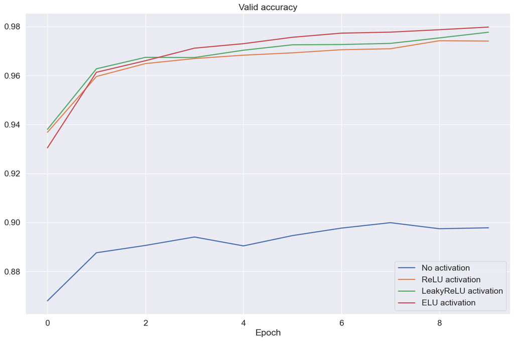

```python
sns.set(style="darkgrid", font_scale=1.4)

plt.figure(figsize=(16, 10))
plt.title("Valid accuracy")
plt.plot(range(max_epochs), plain_accuracy, label="No activation", linewidth=2)
plt.plot(range(max_epochs), relu_accuracy, label="ReLU activation", linewidth=2)
plt.plot(range(max_epochs), leaky_relu_accuracy, label="LeakyReLU activation", linewidth=2)
plt.plot(range(max_epochs), elu_accuracy, label="ELU activation", linewidth=2)
plt.legend()
plt.xlabel("Epoch")
plt.show()
```

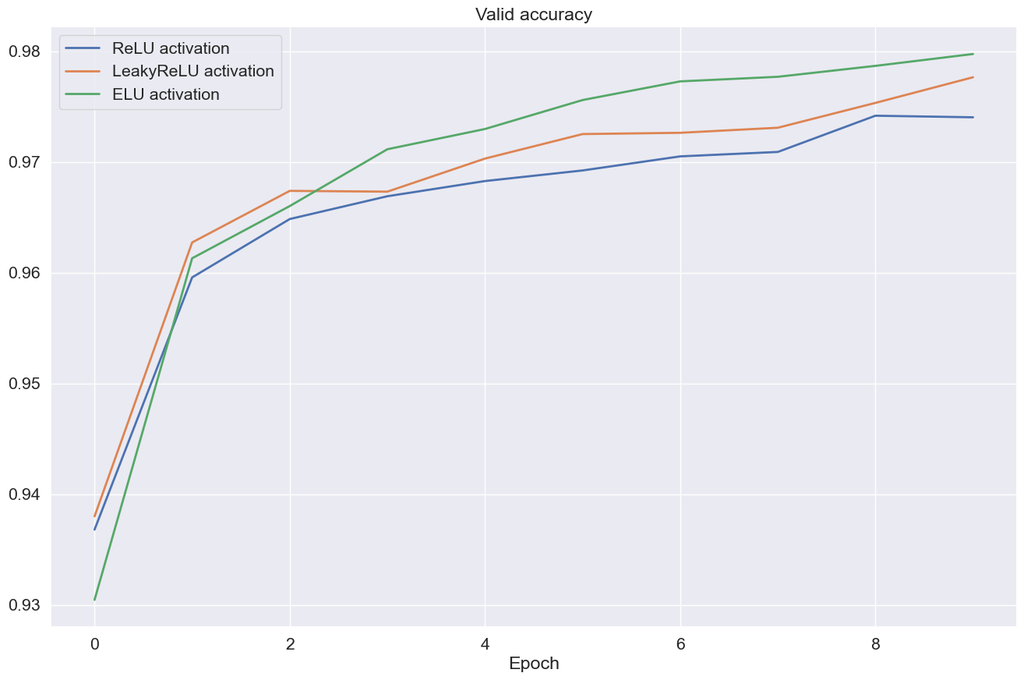

```python
plt.figure(figsize=(16, 10))
plt.title("Valid accuracy")
plt.plot(range(max_epochs), relu_accuracy, label="ReLU activation", linewidth=2)
plt.plot(range(max_epochs), leaky_relu_accuracy, label="LeakyReLU activation", linewidth=2)
plt.plot(range(max_epochs), elu_accuracy, label="ELU activation", linewidth=2)
plt.legend()
plt.xlabel("Epoch")
plt.show()
```

**Вопрос 4** Какая из активаций показала наивысший `accuracy`?

**Ответ:**. ELU

## Сверточные слои

### Ядра

[figure not shown]

[figure not shown]

```python
import cv2
sns.set(style="white")
img = cv2.imread("./images/surf.JPG")
RGB_img = cv2.cvtColor(img, cv2.COLOR_BGR2RGB)
plt.figure(figsize=(12, 8))
plt.imshow(RGB_img)
plt.show()
```

Попробуйте посмотреть как различные свертки влияют на фото. Например, попробуйте  
A)

```
[0, 0, 0],
[0, 1, 0],
[0, 0, 0]
```

Б)

```
[0, 1, 0],
[0, -2, 0],
[0, 1, 0]
```

В)

```
[0, 0, 0],
[1, -2, 1],
[0, 0, 0]
```

Г)

```
[0, 1, 0],
[1, -4, 1],
[0, 1, 0]
```

Д)

```
[0, -1, 0],
[-1, 5, -1],
[0, -1, 0]
```

Е)

```
[0.0625, 0.125, 0.0625],
[0.125, 0.25, 0.125],
[0.0625, 0.125, 0.0625]
```

Не стесняйтесь пробовать свои варианты!

```python
img_t = torch.from_numpy(RGB_img).type(torch.float32).unsqueeze(0)
kernel = torch.tensor([
    [0, 0, 0],
    [1, -2, 1],
    [0, 0, 0]
]).reshape(1, 1, 3, 3).type(torch.float32)

kernel = kernel.repeat(3, 1, 1, 1)
img_t = img_t.permute(0, 3, 1, 2)  # [BS, H, W, C] -> [BS, C, H, W]
img_t = nn.ReflectionPad2d(1)(img_t)  # Pad Image for same output size

result = F.conv2d(img_t, kernel, groups=3)[0]  #
```

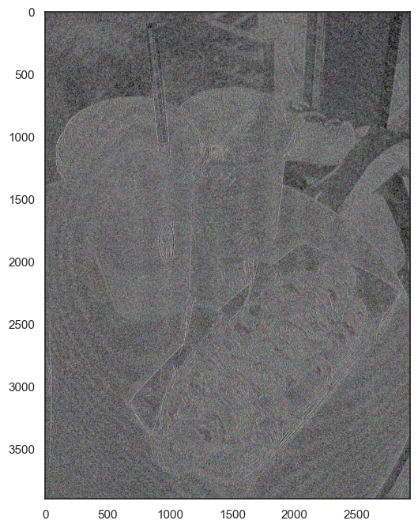

```python
plt.figure(figsize=(12, 8))
result_np = result.permute(1, 2, 0).numpy().astype(np.uint8)

plt.imshow(result_np, cmap="grey")
plt.show()
```

**Вопрос 5** Как вы считаете, как можно описать действия ядер, приведенных выше? Сопоставьте для каждой буквы число.

1. Размытие
2. Увеличение резкости
3. Тождественное преобразование
4. Выделение вертикальных границ
5. Выделение горизонтальных границ
6. Выделение границ

**Ответ:**. A-3 Б-4 В-5 Г-6 Д-2 Е-1

### LeNet

Если мы сделаем параметры сверток обучаемыми, то можем добиться хороших результатов для задач компьютерного зрения. Давайте посмотрим на архитектуру, предложенную еще в 1998 году!

```python
class LeNet(nn.Module):
    def __init__(self):
        super(LeNet, self).__init__()
        # 1 input image channel, 6 output channels, 3x3 square conv kernel
        self.conv1 = nn.Conv2d(1, 6, 3)
        self.conv2 = nn.Conv2d(6, 16, 3)
        self.fc1 = nn.Linear(16 * 5 * 5, 120)  # 5x5 image dimension
        self.fc2 = nn.Linear(120, 84)
        self.fc3 = nn.Linear(84, 10)

    def forward(self, x):
        x = F.max_pool2d(F.relu(self.conv1(x)), (2, 2))
        x = F.max_pool2d(F.relu(self.conv2(x)), 2)
        x = x.view(-1, int(x.nelement() / x.shape[0]))
        x = F.relu(self.fc1(x))
        x = F.relu(self.fc2(x))
        x = self.fc3(x)
        return x
```

```python
model = LeNet()

criterion = nn.CrossEntropyLoss()
optimizer = torch.optim.Adam(model.parameters())

loaders = {"train": train_dataloader, "valid": valid_dataloader}
```

```python
max_epochs = 10
accuracy = {"train": [], "valid": []}
for epoch in range(max_epochs):
    epoch_correct = 0
    epoch_all = 0
    manual_seed(42 + epoch)
    for k, dataloader in loaders.items():
        for x_batch, y_batch in tqdm(dataloader, leave=False):
            if k == "train":
                model.train()
                optimizer.zero_grad()
                outp = model(x_batch)
                loss = criterion(outp, y_batch)
                loss.backward()
                optimizer.step()
            else:
                 model.eval()
                 with torch.no_grad():
                     outp = model(x_batch)

            preds = outp.argmax(-1)
            correct = (preds == y_batch).sum()
            all = y_batch.size(0)
            epoch_correct += correct.item()
            epoch_all += all

        if k == "train":
            print(f"Epoch: {epoch+1}")
        print(f"Loader: {k}. Accuracy: {epoch_correct/epoch_all}")
        accuracy[k].append(epoch_correct/epoch_all)
```

```
Epoch: 1
Loader: train. Accuracy: 0.9589166666666666
```

```
Loader: valid. Accuracy: 0.9596285714285714
```

```
Epoch: 2
Loader: train. Accuracy: 0.9779666666666667
```

```
Loader: valid. Accuracy: 0.9776285714285714
```

```
Epoch: 3
Loader: train. Accuracy: 0.9803166666666666
```

```
Loader: valid. Accuracy: 0.9796857142857143
```

```
Epoch: 4
Loader: train. Accuracy: 0.9799166666666667
```

```
Loader: valid. Accuracy: 0.9786285714285714
```

```
Epoch: 5
Loader: train. Accuracy: 0.9816333333333334
```

```
Loader: valid. Accuracy: 0.9785285714285714
```

```
Epoch: 6
Loader: train. Accuracy: 0.9815833333333334
```

```
Loader: valid. Accuracy: 0.9796857142857143
```

```
Epoch: 7
Loader: train. Accuracy: 0.9806333333333334
```

```
Loader: valid. Accuracy: 0.9784857142857143
```

```
Epoch: 8
Loader: train. Accuracy: 0.9817
```

```
Loader: valid. Accuracy: 0.9802
```

```
Epoch: 9
Loader: train. Accuracy: 0.9819666666666667
```

```
Loader: valid. Accuracy: 0.9802571428571428
```

```
Epoch: 10
Loader: train. Accuracy: 0.9801
```

```
Loader: valid. Accuracy: 0.979
```

```python
lenet_accuracy = accuracy["valid"]
```

Сравним с предыдущем пунктом

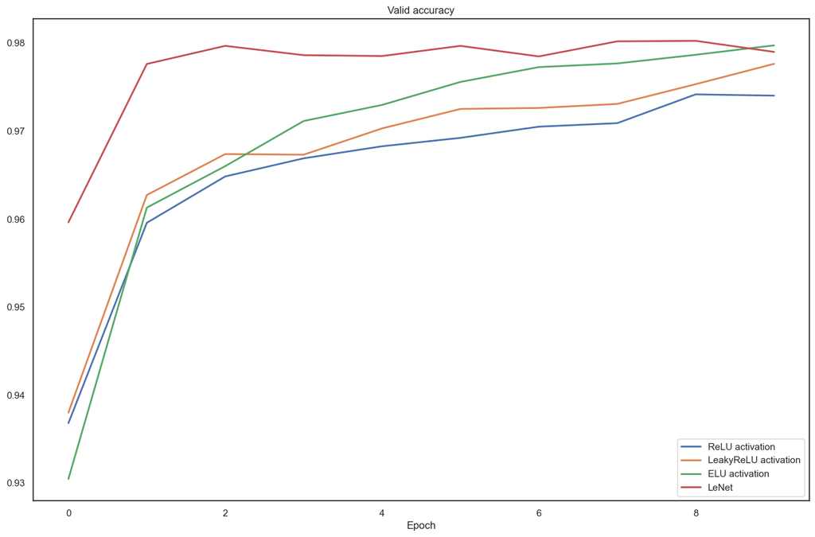

```python
plt.figure(figsize=(16, 10))
plt.title("Valid accuracy")
plt.plot(range(max_epochs), relu_accuracy, label="ReLU activation", linewidth=2)
plt.plot(range(max_epochs), leaky_relu_accuracy, label="LeakyReLU activation", linewidth=2)
plt.plot(range(max_epochs), elu_accuracy, label="ELU activation", linewidth=2)
plt.plot(range(max_epochs), lenet_accuracy, label="LeNet", linewidth=2)
plt.legend()
plt.xlabel("Epoch")
plt.show()
```

**Вопрос 6** Какое `accuracy` получается после обучения с точностью до двух знаков после запятой?

**Ответ:**. 97.90%